# Lab 3 (Part 2): Re-analysis with a covariate

2026-10-16

# Learning objectives

By the end of this part you should be able to:

1. Explain what a covariate is, and add one to a DESeq2 design formula.
2. Use exploratory plots to check whether a covariate explains structure in your samples.
3. Compare results with and without a covariate and explain why they differ.

# Background: Proper biological context

In the first part of the lab, the `~ condition` model found very few (subjective) differentially expressed genes between KO and WT. After the experiment, the researcher learned one more piece of information that wasn’t in the original sample sheet: the 8 mice came from **three different litters**. This information was technically already hiding in the mouse IDs, since consecutive numbers come from the same litter.

| mouse | litter |
| --- | --- |
| 840, 841, 842, 843 | L1 |
| 857, 858 | L2 |
| 891, 892 | L3 |

Mice from the same litter share parents, a mother, a cage, and a birth date. That can make littermates’ gene expression more similar to each other than to mice from other litters, regardless of genotype.

We will re-visit a similar phenomenon later in the semester when we talk about single cell.

A **covariate** is a variable that isn’t what you’re testing but still affects your measurements. If you leave it out of the model, the variation it causes gets counted as noise, and the real effect you care about can get lost in that noise.

**Q0.1** Look back at the mouse IDs in your PCA and heatmap from the first part. Does litter match the structure you saw?

# Part 1: Set up the data

## 1.1 Packages

```r
library(tidyverse)
library(DESeq2)
library(pheatmap)
library(RColorBrewer)
```

## 1.2 Read and clean the counts

This is the same code as the first part of the lab.

```r
counts <- read_tsv("all_verse_counts.tsv") %>%
  select(-1) %>%                                   # drop the leftover row-number column
  rename_with(~ str_remove(.x, "_count"))          # remove "_count" from every column name
```

## 1.3 Add litter to the sample table

```r
coldata <- tibble(sample = colnames(counts)[-1]) %>%
  separate(sample, into = c("condition", "mouse"), remove = FALSE) %>%
  mutate(condition = factor(condition, levels = c("WT", "KO")))


# We make a new tibble that
litter_map <- tibble(
  mouse  = c("840", "841", "842", "843", "857", "858", "891", "892"),
  litter = c(rep("L1", 4), rep("L2", 2), rep("L3", 2))
)
```

We are going to take advantage of columns that hold the same information in each table to perform what’s known as a `join` operation. Specifically, we are going to use a `left_join` which will keep all entries from the dataframe on the `left` even if there is no corresponding match in the `right` dataframe. We are able to do this because the common elements (mouse column) match in both dataframes.

Look up the syntax for `left_join` in tidyverse and join the two tables:

```r
# TODO: left_join litter_map onto coldata; make litter a factor
coldata <- coldata %>%
  left_join(litter_map, by = "mouse") %>%
  mutate(litter = factor(litter))
coldata
```

```
## # A tibble: 8 × 4
##   sample condition mouse litter
##   <chr>  <fct>     <chr> <fct>
## 1 WT_842 WT        842   L1
## 2 KO_857 KO        857   L2
## 3 WT_892 WT        892   L3
## 4 KO_891 KO        891   L3
## 5 WT_841 WT        841   L1
## 6 KO_843 KO        843   L1
## 7 WT_858 WT        858   L2
## 8 KO_840 KO        840   L1
```

**Q1.1** Make a table of `condition` by `litter` with `table(coldata$condition, coldata$litter)`. Does every litter contain both WT and KO mice?

```r
table(coldata$condition, coldata$litter)
```

```
##
##      L1 L2 L3
##   WT  2  1  1
##   KO  2  1  1
```

## 1.4 Build the DESeq2 object

```r
mat <- counts %>% column_to_rownames("gene_id") %>% as.matrix()

dds_cov <- DESeqDataSetFromMatrix(countData = mat,
                                  colData   = coldata,
                                  design    = ~ litter + condition)

# Same filter as the first part of the lab
keep <- rowSums(counts(dds_cov) >= 10) >= 4
dds_cov <- dds_cov[keep, ]
```

# Part 2: Does litter explain the structure?

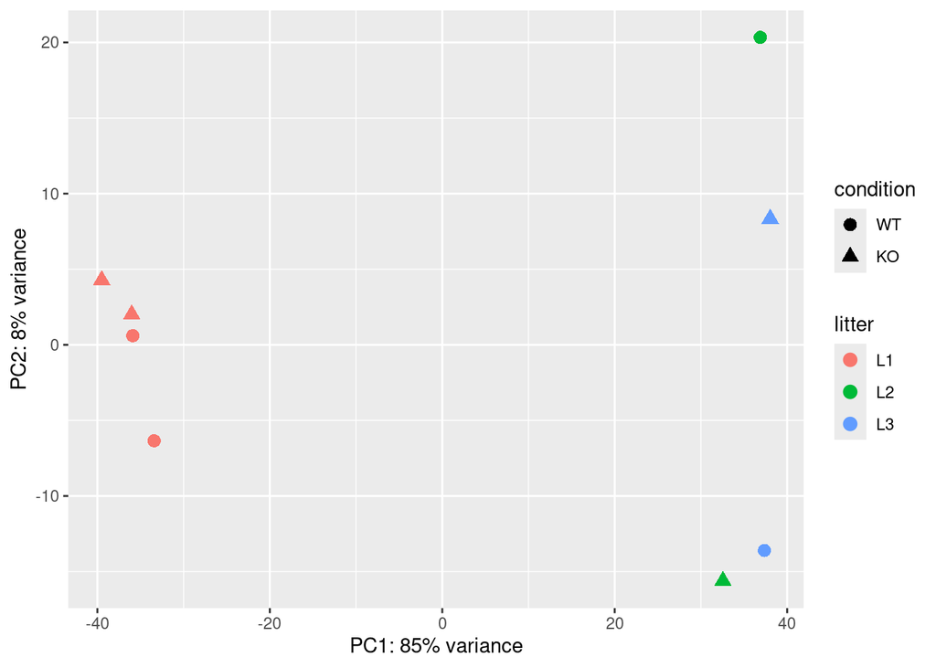

```r
vsd <- vst(dds_cov, blind = TRUE)

pca_df <- plotPCA(vsd, intgroup = c("condition", "litter"), returnData = TRUE)
percentVar <- round(100 * attr(pca_df, "percentVar"))

ggplot(pca_df, aes(x = PC1, y = PC2, color = litter, shape = condition)) +
  geom_point(size = 3) +
  labs(x = paste0("PC1: ", percentVar[1], "% variance"),
       y = paste0("PC2: ", percentVar[2], "% variance"))
```

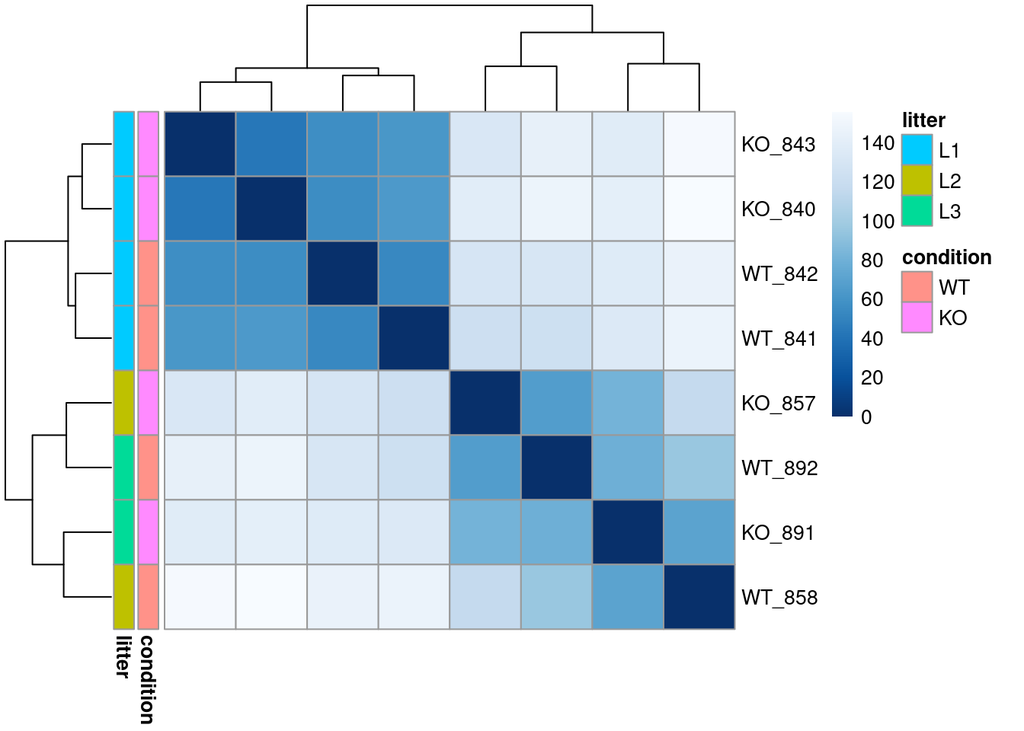

```r
sampleDists <- dist(t(assay(vsd)))
sampleDistMatrix <- as.matrix(sampleDists)
anno <- as.data.frame(colData(vsd)[, c("condition", "litter")])
colors <- colorRampPalette(rev(brewer.pal(9, "Blues")))(255)
pheatmap(sampleDistMatrix,
         clustering_distance_rows = sampleDists,
         clustering_distance_cols = sampleDists,
         annotation_row = anno,
         show_colnames = FALSE,
         col = colors)
```

**Q2.1** What does PC1 separate now that the points are colored by litter?

**Q2.2** In the heatmap, do samples cluster by litter or by genotype?

# Part 3: Comparing the two models

We fit both models on the same filtered data so the comparison is fair.

```r
# The original model: ~ condition
dds_naive <- dds_cov
design(dds_naive) <- ~ condition
dds_naive <- DESeq(dds_naive)
res_naive <- results(dds_naive, name = "condition_KO_vs_WT")

# The revisited model: ~ litter + condition
dds_cov <- DESeq(dds_cov)
res_cov <- results(dds_cov, name = "condition_KO_vs_WT")
```

```r
# TODO: convert res_cov to a tibble, arrange by padj
res_tbl <- res_cov %>% as_tibble(rownames = "gene_id") %>% arrange(padj)
res_tbl
```

```
## # A tibble: 15,788 × 7
##    gene_id               baseMean log2FoldChange lfcSE   stat   pvalue     padj
##    <chr>                    <dbl>          <dbl> <dbl>  <dbl>    <dbl>    <dbl>
##  1 ENSMUSG00000017639.13     578.          -1.79 0.157 -11.4  3.80e-30 5.54e-26
##  2 ENSMUSG00000082536.1     1518.          -3.67 0.326 -11.3  2.27e-29 1.65e-25
##  3 ENSMUSG00000022912.8     3957.          -1.46 0.143 -10.2  2.87e-24 1.39e-20
##  4 ENSMUSG00000055027.17     329.          -2.25 0.243  -9.26 1.95e-20 7.11e-17
##  5 ENSMUSG00000104802.1      249.          -3.54 0.396  -8.95 3.64e-19 1.06e-15
##  6 ENSMUSG00000075254.11   10661.          -1.30 0.148  -8.78 1.69e-18 4.10e-15
##  7 ENSMUSG00000032946.16     441.          -1.38 0.164  -8.41 4.00e-17 8.32e-14
##  8 ENSMUSG00000027875.12    2069.          -2.67 0.324  -8.23 1.82e-16 3.32e-13
##  9 ENSMUSG00000026043.18   43585.          -1.60 0.203  -7.89 3.14e-15 5.08e-12
## 10 ENSMUSG00000025780.7    59155.          -1.03 0.132  -7.79 6.60e-15 9.61e-12
## # ℹ 15,778 more rows
```

**Q3.1** How many genes are significant at `padj < 0.1` in each model?

```r
sum(res_naive$padj < 0.1, na.rm = TRUE)
```

```
## [1] 146
```

```r
sum(res_cov$padj < 0.1, na.rm = TRUE)
```

```
## [1] 759
```

# Part 4: Genes gained by adding the covariate

The code for this section is provided. Read through it and run each chunk.

```r
# Significant genes (padj < 0.1) from each model
sig_naive <- res_naive %>%
  as.data.frame() %>%
  rownames_to_column("gene_id") %>%
  filter(padj < 0.1) %>%
  pull(gene_id)

sig_cov <- res_cov %>%
  as.data.frame() %>%
  rownames_to_column("gene_id") %>%
  filter(padj < 0.1) %>%
  arrange(padj)

# Genes significant ONLY after adding litter to the model
gained <- sig_cov %>% filter(!gene_id %in% sig_naive)
nrow(gained)
```

```
## [1] 615
```

```r
head(gained)
```

```
##                 gene_id   baseMean log2FoldChange     lfcSE      stat
## 1 ENSMUSG00000075254.11 10660.8047     -1.2964349 0.1477206 -8.776263
## 2 ENSMUSG00000026043.18 43585.3423     -1.6001509 0.2029286 -7.885291
## 3  ENSMUSG00000025780.7 59155.2113     -1.0301090 0.1322014 -7.791967
## 4 ENSMUSG00000010051.15   987.2795     -1.4605682 0.1992715 -7.329540
## 5 ENSMUSG00000025579.14  9687.0191     -0.7927905 0.1122631 -7.061897
## 6  ENSMUSG00000024899.6  3367.2054     -0.8266911 0.1209755 -6.833541
##         pvalue         padj
## 1 1.689960e-18 4.101814e-15
## 2 3.138031e-15 5.077683e-12
## 3 6.597419e-15 9.607822e-12
## 4 2.309447e-13 2.689282e-10
## 5 1.642444e-12 1.406995e-09
## 6 8.284409e-12 6.032292e-09
```

```r
# Pick the top gained gene. To look at a different one, replace this with any
# gene_id from the `gained` table, e.g. gene_of_interest <- "ENSMUSG00000030172.15"
gene_of_interest <- gained$gene_id[1]

# Compare its statistics in the two models
tibble(
  model          = c("~ condition", "~ litter + condition"),
  log2FoldChange = c(res_naive[gene_of_interest, "log2FoldChange"],
                     res_cov[gene_of_interest, "log2FoldChange"]),
  padj           = c(res_naive[gene_of_interest, "padj"],
                     res_cov[gene_of_interest, "padj"])
)
```

```
## # A tibble: 2 × 3
##   model                log2FoldChange     padj
##   <chr>                         <dbl>    <dbl>
## 1 ~ condition                   -1.40 6.53e- 1
## 2 ~ litter + condition          -1.30 4.10e-15
```

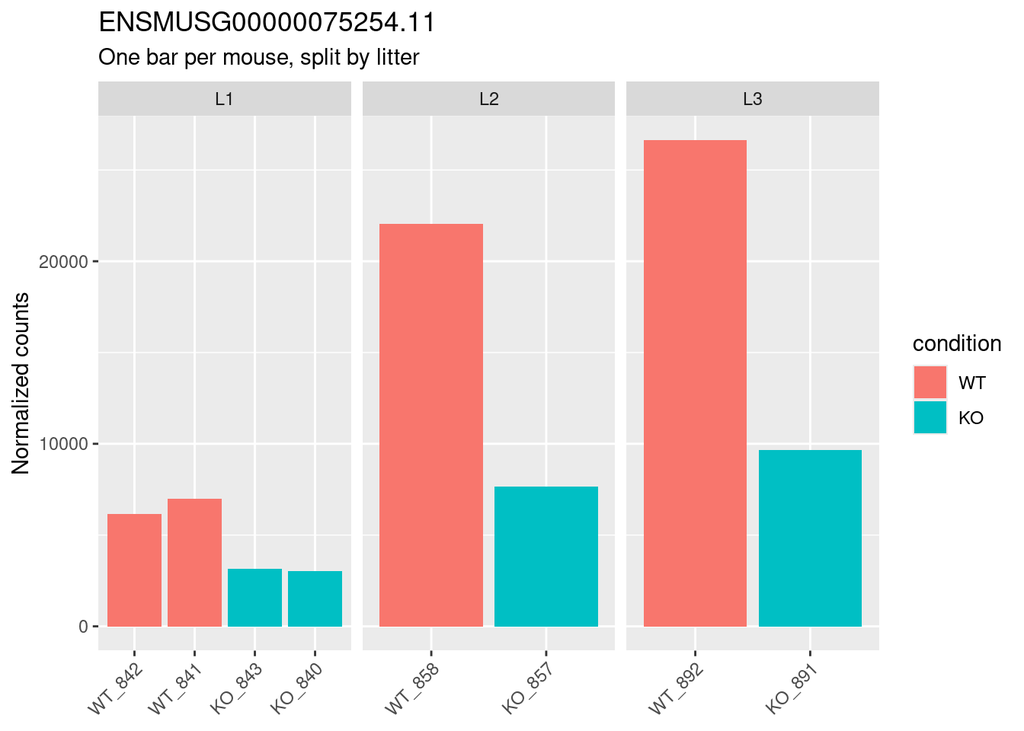

```r
# Normalized counts for that gene, joined to the sample info (condition, litter)
plot_df <- counts(dds_cov, normalized = TRUE)[gene_of_interest, ] %>%
  enframe(name = "sample", value = "norm_count") %>%
  left_join(as.data.frame(colData(dds_cov)), by = "sample")

# View 1: one bar per mouse, grouped by litter, WT before KO within each litter
plot_df <- plot_df %>% arrange(litter, condition) %>%
  mutate(sample = factor(sample, levels = sample))

ggplot(plot_df, aes(x = sample, y = norm_count, fill = condition)) +
  geom_col() +
  facet_wrap(~ litter, scales = "free_x") +
  labs(title = gene_of_interest, subtitle = "One bar per mouse, split by litter",
       x = NULL, y = "Normalized counts") +
  theme(axis.text.x = element_text(angle = 45, hjust = 1))
```

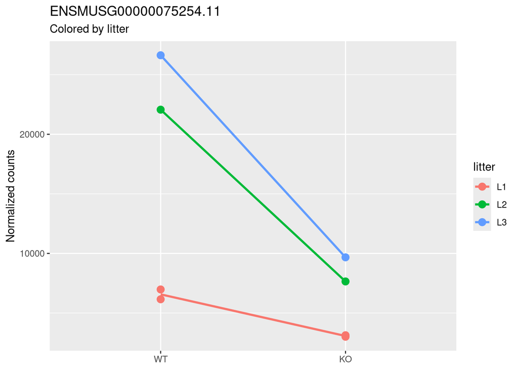

```r
# View 2: the same points, colored by litter, with each litter's WT and KO means joined
ggplot(plot_df, aes(x = condition, y = norm_count, color = litter)) +
  geom_point(size = 3) +
  stat_summary(aes(group = litter), fun = mean, geom = "line", linewidth = 1) +
  labs(title = gene_of_interest, subtitle = "Colored by litter",
       x = NULL, y = "Normalized counts")
```

**Q4** Change `gene_of_interest` to two or three other genes from `gained` and re-run the plots. Is the pattern the same?

# Part 5: Other things you’re asked to do in Project 2

## Joining the gene names

Your pipeline should have generated a delimited-file that contains the mapping of every ensemble gene ID to its corresponding gene symbol (human readable gene names).

Once you have performed differential expression, you’ll often want to convert those IDs to symbols to be more easily interpretable. As above, you would first read in the gene id to symbol mapping into a tibble based on how your file is delimited, `read_csv` for commas and `read_tsv` for tabs. You woudl then use a `join` to join that tables information (gene symbol) into the DE results table on the common column (gene_id). You will need to look at the function definition to handle the situation where your columns that hold the keys have different names.

You can practice here with the included file. Remember that this is species-specific, so this will only be valid for mice.

## Generating a ranked list of genes by Log2FoldChange

Once you have joined the gene names into your DE results table, you can use a combination of `select`, `arrange`, and `pull` to generate a ranked list of gene names and their associated fold change value.

## Generating a list of significant genes

With your DE results table, you can use `filter` to generate just a table containing genes meeting your significance threshold. You can then write only these results to a new file so that you can easily copy / paste them into DAVID or Enrichr.

## Running FGSEA

You will need to download a GMT file (format for holding gene sets) from the MSigDB website and upload it to your repo. The `fgsea` package includes some helper functions that will read the GMT file into the appropriate format that it needs.

## Plotting

We will not be covering plotting in depth in this course. You are not expected to memorize ggplot syntax, but you are expected to be able to read generated plotting code well enough to tell what data it uses and what it does to that data. If you need a refresher, the data visualization chapters of R for Data Science (r4ds.hadley.nz) are a good starting point.

Plotting can be quite challenging, in part because every plotting library has its own style and logic that you have to learn. In R, ggplot2 is built on the grammar of graphics, where you map columns of your data to aesthetics and add layers one at a time. Base R plotting works more like drawing on a canvas, one command after another. In Python, matplotlib is notoriously opaque: it offers two overlapping interfaces (the state-based pyplot style and the object-oriented figure/axes style), and even simple customizations can require large amounts of time reading about layers of objects and documentation. Fluency in one of these does not transfer neatly to another, and remembering the exact syntax for a specific tweak is often more trouble than it’s worth.

This is where LLMs can genuinely help. Generating plotting code is one of the relatively safer things they can do. Unlike an analysis step, where a subtle error can change your results, a plotting error is usually visible: you can look at the figure and check it against the numbers in your data. We should always be mindful of distorting our data, but the risk is lower as long as you verify what you see. Adding on to this, most plotting code in ggplot can be written such that any transformations like filter or arrange happen through a pipe and therefore leave the original data untouched.

Before accepting a generated plot, ask yourself a few questions. Does the plot use the columns you intended (for example, adjusted p-values rather than raw p-values in a volcano plot)? Are the axes, scales, and transformations appropriate and clearly labeled? Do the patterns in the plot agree with what you see when you inspect the underlying table directly, such as the number of significant genes or the direction of the largest fold changes? Has anything been dropped, filtered, or changed without your knowledge? You can inspect the magnitude and range of the values in the underlying table and check to see if those are reflected in your plot.

Treat the LLM as a fast way to get a first draft of the code to generate a plot, and ensure that you critically review it.